# pml project

Elisa Lerner

15 November 2015

```r
library(caret)
library(mlbench)
data <- read.csv("pml-training.csv")
test <- read.csv("pml-testing.csv")
```

The raw datset includes 19622 observations of 160 variables.  
This is a classification problem - there are 5 classes to identify: A,B,C,D,E. The first step is to decide which of the variables to use as predictors.

```r
str(data)
```

```
## 'data.frame':    19622 obs. of  160 variables:
##  $ X                       : int  1 2 3 4 5 6 7 8 9 10 ...
##  $ user_name               : Factor w/ 6 levels "adelmo","carlitos",..: 2 2 2 2 2 2 2 2 2 2 ...
##  $ raw_timestamp_part_1    : int  1323084231 1323084231 1323084231 1323084232 1323084232 1323084232 1323084232 1323084232 1323084232 1323084232 ...
##  $ raw_timestamp_part_2    : int  788290 808298 820366 120339 196328 304277 368296 440390 484323 484434 ...
##  $ cvtd_timestamp          : Factor w/ 20 levels "02/12/2011 13:32",..: 9 9 9 9 9 9 9 9 9 9 ...
##  $ new_window              : Factor w/ 2 levels "no","yes": 1 1 1 1 1 1 1 1 1 1 ...
##  $ num_window              : int  11 11 11 12 12 12 12 12 12 12 ...
##  $ roll_belt               : num  1.41 1.41 1.42 1.48 1.48 1.45 1.42 1.42 1.43 1.45 ...
##  $ pitch_belt              : num  8.07 8.07 8.07 8.05 8.07 8.06 8.09 8.13 8.16 8.17 ...
##  $ yaw_belt                : num  -94.4 -94.4 -94.4 -94.4 -94.4 -94.4 -94.4 -94.4 -94.4 -94.4 ...
##  $ total_accel_belt        : int  3 3 3 3 3 3 3 3 3 3 ...
##  $ kurtosis_roll_belt      : Factor w/ 397 levels "","-0.016850",..: 1 1 1 1 1 1 1 1 1 1 ...
##  $ kurtosis_picth_belt     : Factor w/ 317 levels "","-0.021887",..: 1 1 1 1 1 1 1 1 1 1 ...
##  $ kurtosis_yaw_belt       : Factor w/ 2 levels "","#DIV/0!": 1 1 1 1 1 1 1 1 1 1 ...
```

[output cut: 86 more lines]

Many of the variables contain NA’s. I would like to see how many NA’s there actually are in each column.

```r
nas<-apply(data, MARGIN = 2, FUN = function(x) length(x[is.na(x)]) )
unique(nas)
```

```
## [1]     0 19216
```

It turns out that either variables have no NA’s, or a large proportion ( equally large for all variables that do have NA’s), so it seems reasonable to discard these variables.

```r
#remove variables that are mostly NA
use<-data[,nas==0]
testUse <- test[,nas==0]
```

The first few columns appear to hold data that are not measurements made by the equipment and don’t have any physical relationship with the outcome, so these are also discarded.

```r
#remove variables that are not measurements of movements
l <-dim(use)[2]
use <- use[,8:l]
testUse <- testUse[,8:l]
```

Since multiple measurements were made of all the actions using the different sorts of equipment it is probable that some of the variables are highly correlated, so not all should be included in the model. Pairwise correlations between the variables are made and highly correlated variables (greater than 0.75) are discarded.

```r
#transform factor variables to numeric for correlation computations only
temp<-use
for(i in 1:dim(temp)[2]-1){
        if(is.factor(temp[,i])){
               temp[,i]<-as.numeric(temp[,i])
        }

}

# calculate correlation matrix
correlationMatrix <- cor(temp[,-dim(temp)[2]])
# find variables that are highly corrected
highCorr <- findCorrelation(correlationMatrix, cutoff=0.75)
#remove these variables;retain original classes of features
use<-use[-highCorr]
testUse <- testUse[-highCorr]
```

Finally, variables with very low variance are also discarded since they will be unable to explain variability in the data.

```r
#remove variables with near zero variance
nzv <- nearZeroVar(use,saveMetrics=TRUE)
use <- use[,!nzv$nzv]
testUse <- testUse[,!nzv$nzv]
```

The dataset now has 32 variables which will be used as predictors for the outcome, classe. 3-Fold cross validation is defined for the model.

```r
fitControl <- trainControl(method = "repeatedcv", number = 3,repeats = 1, verbose = FALSE,returnResamp = "all")
modFit <- train(classe~.,method="rpart",data=use,trControl=fitControl)
modFit$results
```

```
##           cp  Accuracy     Kappa AccuracySD    KappaSD
## 1 0.02741775 0.5227797 0.4002618 0.01815767 0.02123497
## 2 0.02934055 0.5166144 0.3922863 0.01063087 0.01142797
## 3 0.04226606 0.3571863 0.1251951 0.12606315 0.21684428
```

The model fitted by the ‘rpart’ method is disappointing, resulting in accuracy of only about 50%. There is no point using this method on the testing data.

Boosting is known to improve prediction:

```r
modFit <- train(classe~.,method="gbm",data=use,trControl=fitControl,verbose=FALSE)

modFit$finalModel
```

```
## A gradient boosted model with multinomial loss function.
## 150 iterations were performed.
## There were 32 predictors of which 30 had non-zero influence.
```

```r
modFit$results
```

```
##   shrinkage interaction.depth n.minobsinnode n.trees  Accuracy     Kappa
## 1       0.1                 1             10      50 0.7156247 0.6395033
## 4       0.1                 2             10      50 0.8207114 0.7728783
## 7       0.1                 3             10      50 0.8683110 0.8332943
## 2       0.1                 1             10     100 0.7732645 0.7129648
## 5       0.1                 2             10     100 0.8791151 0.8470514
## 8       0.1                 3             10     100 0.9216695 0.9008772
## 3       0.1                 1             10     150 0.8089388 0.7582573
## 6       0.1                 2             10     150 0.9093872 0.8853269
## 9       0.1                 3             10     150 0.9465394 0.9323551
##    AccuracySD     KappaSD
## 1 0.010887267 0.013612273
## 4 0.005796391 0.007373789
## 7 0.007555580 0.009540134
## 2 0.006676155 0.008469768
## 5 0.007130331 0.009015560
## 8 0.005791922 0.007341841
## 3 0.008830034 0.011204776
## 6 0.007110118 0.009000101
## 9 0.003842004 0.004875293
```

So the accuracy has shot up to 0.9465394 thanks to the boosting algorithm. This implies an estimate of the out of sample error to be 0.0534606.

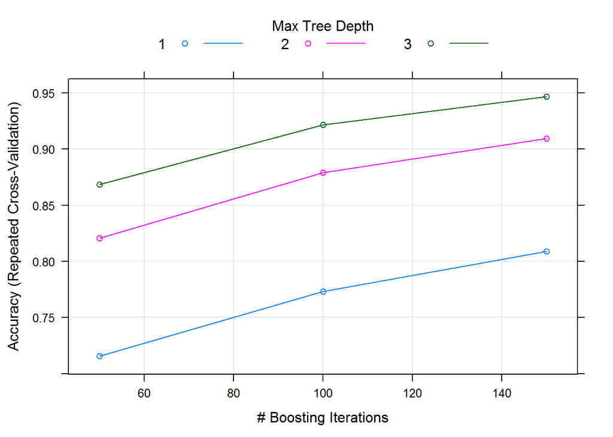

Perhaps this can be further improved by trying a different algorithm.  
Random forests generates the following model:

```r
modFit <- train(classe~.,method="rf",prox=TRUE,data=use,trControl=fitControl,verbose=FALSE)

modFit$finalModel
```

```
##
## Call:
##  randomForest(x = x, y = y, mtry = param$mtry, proximity = TRUE,      verbose = FALSE)
##                Type of random forest: classification
##                      Number of trees: 500
## No. of variables tried at each split: 2
##
##         OOB estimate of  error rate: 0.52%
## Confusion matrix:
##      A    B    C    D    E  class.error
## A 5579    1    0    0    0 0.0001792115
## B   12 3777    8    0    0 0.0052673163
## C    0   15 3395   12    0 0.0078901227
## D    0    0   44 3168    4 0.0149253731
## E    0    0    1    5 3601 0.0016634322
```

```r
modFit$results
```

```
##   mtry  Accuracy     Kappa   AccuracySD      KappaSD
## 1    2 0.9924574 0.9904580 0.0007224337 0.0009134929
## 2   17 0.9908780 0.9884603 0.0026826108 0.0033930573
## 3   32 0.9794115 0.9739544 0.0044327173 0.0056058947
```

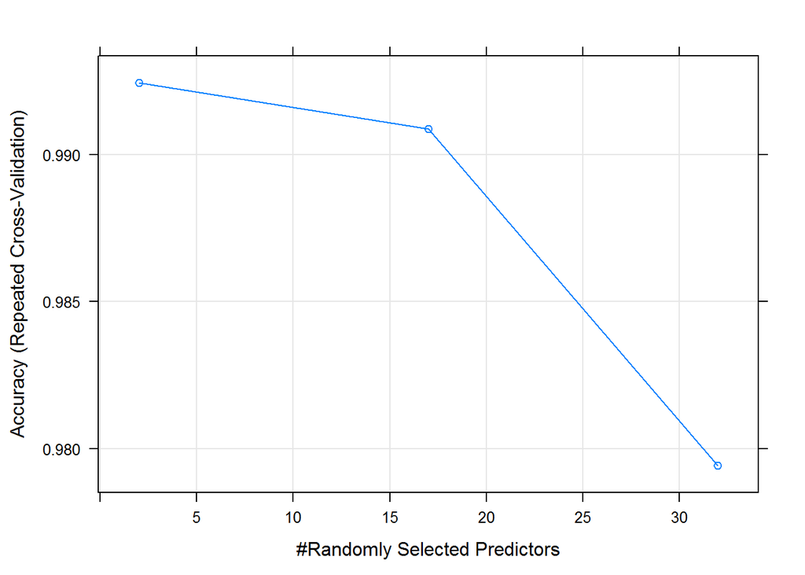

```r
plot(modFit)
```

The accuracy is now 0.9924574, hence estimate of out of sample error being 0.0075426. With such a small error it should be possible to correctly predict 20 out of 20 test cases.

Now, applying to the testing data gives the following predictions:

```r
predict(modFit,testUse)
```

```
##  [1] B A B A A E D B A A B C B A E E A B B B
## Levels: A B C D E
```